# Hotel booking demand

## 仓库地址：https://github.com/VicenTYC/DM-Homework3

#### lead_time:在PMS中输入预订日期和到达日期之间经过的天数 stays_in_weekend_nights: 客人在酒店住宿或预订住宿的周末晚上(周六或周日)的数量 stays_in_week_nights : 客人在酒店住宿或预订住宿的工作日晚上(周一至周五) meal: 预订的餐点类型。类别在标准招待套餐中显示：未定义/SC-无餐包；BB：住宿和早餐；HB-半食宿(早餐和另一顿饭-通常是晚餐)；FB-全食宿(早餐、午餐和晚餐) country: 国籍。类别以ISO 3155-3：2013格式表示 market_segment: 细分市场名称。“TA”表示“Travel Agents”，“TO”表示“Tour Operators” distribution_channel： 预订分销渠道“TA”表示“Travel Agents”，“TO”表示“Tour Operators” is_repeated_guest：指示预订名称是否来自重复来宾的值 1或不是 0 previous_cancellations： 客户在本次预订之前取消的以前预订数量 previous_bookings_not_canceled： 客户在本次预订之前未取消的先前预订数量 reserved_room_type：预定房间类型 assigned_room_type：分配房间类型 booking_changes：从预订单输入开始对预订所做的更改/修改的次数 deposit_type：注明客户是否支付了押金以保证预订 agent：预订的旅行社ID company：预订或负责支付预订的公司/实体的ID days_in_waiting_list：确认之前预定等待的天数 customer_type：预定类型 adr：每日平均住宿费，即所有住宿交易总额除以入住总天数 required_car_parking_spaces：要求停车位的数量 total_of_special_requests：客户提出的特殊要求的数量(例如，双人床或高楼) reservation_status：预定的最终状态。结账退房，取消预订等 reservation_status_date：设置最后状态的日期。此变量可与ReservationStatus一起使用

```python
import numpy as np
import pandas as pd
import matplotlib.pyplot as plt
import seaborn as sns
import datetime
```

```python
# 模型训练
from sklearn.model_selection import train_test_split
from sklearn.preprocessing import LabelEncoder
```

```python
# 设置整体绘图打印样式
%config InlineBackend.figure_format='retina'
sns.set()
plt.rcParams['figure.figsize'] = (11, 5)
plt.rcParams['axes.labelpad'] = 10
sns.set_style("darkgrid")
# sns.set_palette("Reds")
# sns.set_context("poster", font_scale=1.0)
```

```python
file_path = "F:\\hotel_bookings.csv"
df = pd.read_csv(file_path)
```

```python
df.isnull().sum()
```

```
hotel                                  0
is_canceled                            0
lead_time                              0
arrival_date_year                      0
arrival_date_month                     0
arrival_date_week_number               0
arrival_date_day_of_month              0
stays_in_weekend_nights                0
stays_in_week_nights                   0
adults                                 0
children                               4
babies                                 0
meal                                   0
country                              488
market_segment                         0
distribution_channel                   0
is_repeated_guest                      0
previous_cancellations                 0
previous_bookings_not_canceled         0
reserved_room_type                     0
assigned_room_type                     0
booking_changes                        0
deposit_type                           0
agent                              16340
company                           112593
days_in_waiting_list                   0
customer_type                          0
adr                                    0
required_car_parking_spaces            0
total_of_special_requests              0
reservation_status                     0
reservation_status_date                0
dtype: int64
```

## 2 数据清洗

### 2.1删除无用的数据列。arrival_date_week_number、company

```python
# 删除无关的属性列
df.drop(['arrival_date_week_number','company'],axis=1,inplace=True)
```

```python
df.isnull().sum()
```

```
hotel                                 0
is_canceled                           0
lead_time                             0
arrival_date_year                     0
arrival_date_month                    0
arrival_date_day_of_month             0
stays_in_weekend_nights               0
stays_in_week_nights                  0
adults                                0
children                              4
babies                                0
meal                                  0
country                             488
market_segment                        0
distribution_channel                  0
is_repeated_guest                     0
previous_cancellations                0
previous_bookings_not_canceled        0
reserved_room_type                    0
assigned_room_type                    0
booking_changes                       0
deposit_type                          0
agent                             16340
days_in_waiting_list                  0
customer_type                         0
adr                                   0
required_car_parking_spaces           0
total_of_special_requests             0
reservation_status                    0
reservation_status_date               0
dtype: int64
```

### 2.2 删除空值元组，并删除掉一些不符合实际的元组（总人数为0）

```python
# 删除childre、country列中的有缺失的元组
df = df.dropna(how="any", subset=["agent"])
df = df.dropna(how="any", subset=["country"])
df = df.dropna(how="any", subset=["children"])
#  由于之前删除数据，首先重置索引
df.reset_index(inplace=True,drop=True)

# 删除总人数为0的元组
o_guests = list(df.loc[df["adults"]
                   + df["children"]
                   + df["babies"]==0].index)
if o_guests is not None:
    df.drop(df.index[o_guests], inplace=True)
```

```python
#将月份转换成数字
month_to_number={'January':1, 'February':2, 'March':3, 'April':4, 'May':5, 'June':6,'July':7, 'August':8, 'September':9, 'October':10, 'November':11, 'December':12 }
df['arrival_date_month']=df['arrival_date_month'].map(lambda x: month_to_number[x])
```

```python
df.isnull().sum()
```

```
hotel                             0
is_canceled                       0
lead_time                         0
arrival_date_year                 0
arrival_date_month                0
arrival_date_day_of_month         0
stays_in_weekend_nights           0
stays_in_week_nights              0
adults                            0
children                          0
babies                            0
meal                              0
country                           0
market_segment                    0
distribution_channel              0
is_repeated_guest                 0
previous_cancellations            0
previous_bookings_not_canceled    0
reserved_room_type                0
assigned_room_type                0
booking_changes                   0
deposit_type                      0
agent                             0
days_in_waiting_list              0
customer_type                     0
adr                               0
required_car_parking_spaces       0
total_of_special_requests         0
reservation_status                0
reservation_status_date           0
dtype: int64
```

## 3 数据探索

### 3.1 城市酒店和假日酒店预订需求和入住率比较

```python
df['hotel'].describe()
```

```
count         102774
unique             2
top       City Hotel
freq           71065
Name: hotel, dtype: object
```

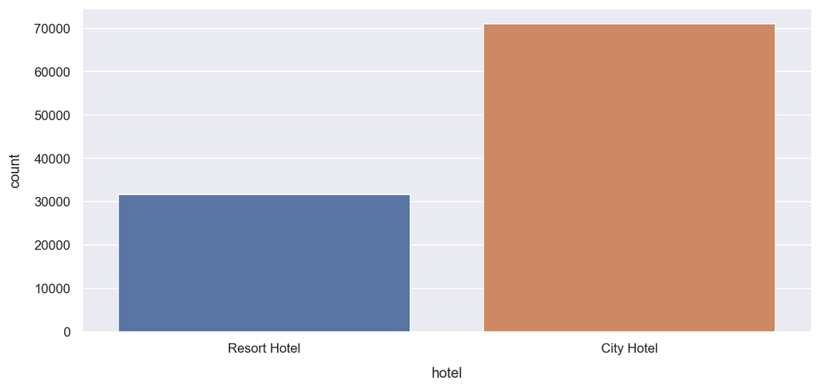

```python
sns.countplot(df['hotel'])
```

```python
cdf= df[df['hotel']=='City Hotel']
rdf = df[df['hotel']=='Resort Hotel']
```

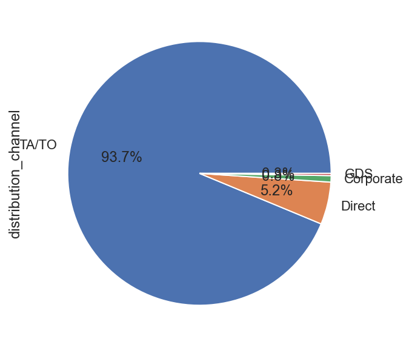

```python
# 城市酒店预订销售渠道
ctypeCount = cdf['distribution_channel'].value_counts()
(ctypeCount/len(cdf)).plot.pie(autopct='%.1f%%')
```

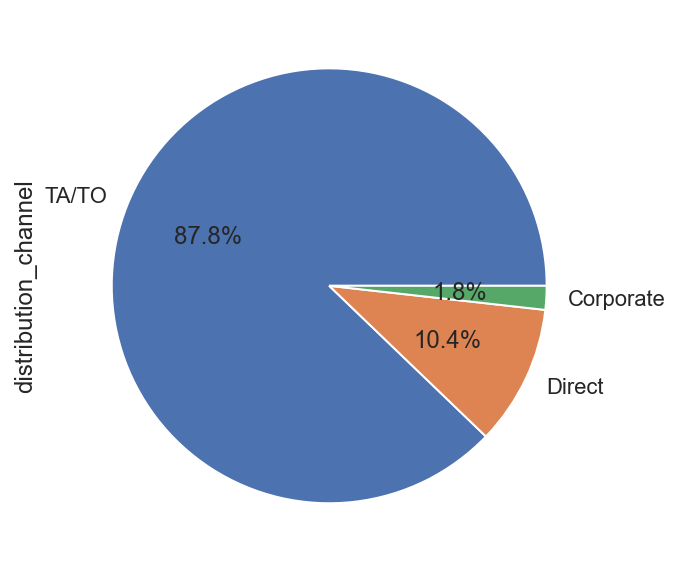

```python
# 假日酒店预订销售渠道
rtypeCount = rdf['distribution_channel'].value_counts()
(rtypeCount/len(rdf)).plot.pie(autopct='%.1f%%')
```

### 通过观察城市酒店和假日酒店预订销售渠道可以看出，两种酒店通过旅行团预订都占绝大比例，其中城市酒店旅行团预订更多占93.7%，而假日酒店则占87.8%。由此可以看出通过旅行团预订的酒店，城市酒店的可能性大，即城市酒店主要接收的预订来自旅行团。

### 同时比较直接预订的比例，发现假日酒店比城市酒店接受更多的个人直接预订。

### 最后，城市酒店比假日酒店多一种GDS的预订渠道，但是该渠道只提供了很少量的宾客。

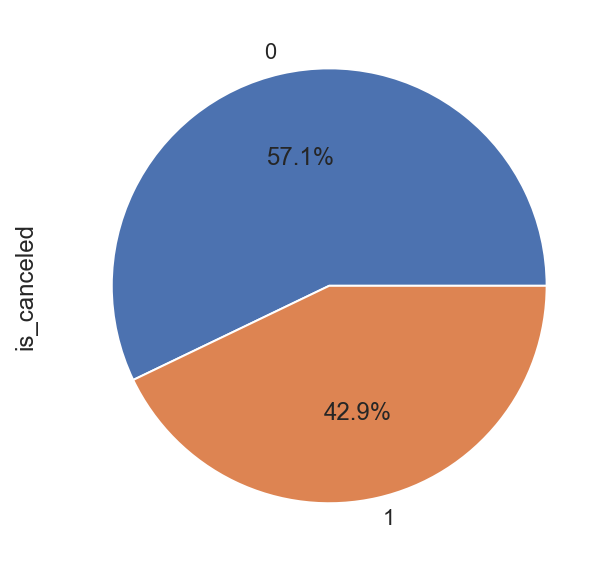

```python
#城市酒店预订取消率 0:未取消；1：取消
ctypeCount = cdf['is_canceled'].value_counts()
(ctypeCount/len(cdf)).plot.pie(autopct='%.1f%%')
```

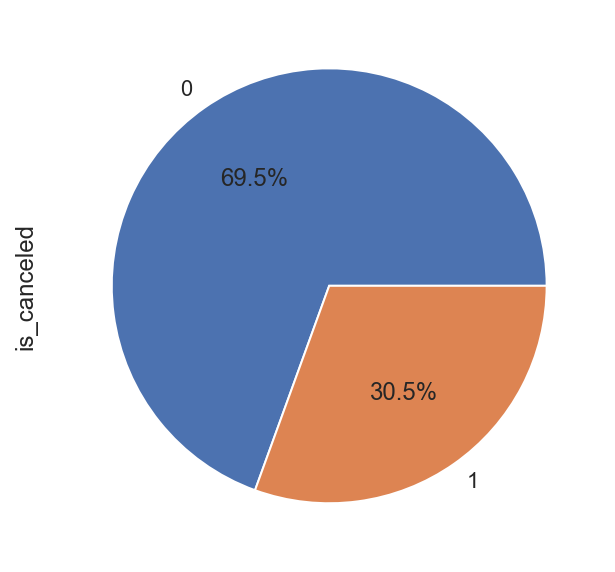

```python
#假日酒店预订取消率 0:未取消；1：取消
rtypeCount = rdf['is_canceled'].value_counts()
(rtypeCount/len(rdf)).plot.pie(autopct='%.1f%%')
```

### 比较两种酒店的预订取消率可以看出，城市酒店的预订取消率更高占预订总量的42.9%, 而假日酒店的入住率更高，占全部预订的69.5%。

### 结合上述虽然城市酒店接受了更多的预订，但同时也拥有更低的入住率，而假日酒店可能由于与度假相关，虽然有更少的预订量，但是有很高的入住率。

### 3.2 用户行为分析：提前预订时间、入住时长、餐食预订情况

#### 为了显示更清晰，对提前预定时间进行分层

```python
def normalizef(x):
    s = x['lead_time']
    if s > 365*2:
        s = 'leadTime'+'2y'
    elif (s > 365+365/2) and (s <= 365*2):
        s = 'leadTime'+'1.5y_2y'
    elif s > 365 and s <= 365+365/2:
        s = 'leadTime'+'1y_1.5y'
    elif s >30*10 and s<=365:
        s = 'leadTime'+'10m_12m'
    elif s >30*8 and s<=30*10:
        s = 'leadTime'+'8m_10m'
    elif s >30*6 and s<=30*8:
        s = 'leadTime'+'6m_8m'
    elif s >30*4 and s<=30*6:
        s = 'leadTime'+'4m_6m'
    elif s >30*2 and s<=30*4:
        s = 'leadTime'+'2m_4m'
    elif s >30 and s<=30*2:
        s = 'leadTime'+'1m_2m'
    elif s >10*2 and s<=30:
        s = 'leadTime'+'20d_30d'
    elif s >10 and s<=10*2:
        s = 'leadTime'+'10d_20d'
    elif s >5 and s<=10:
        s = 'leadTime'+'5d_10d'
    elif s<=5:
        s = 'leadTime'+'5d'
    x['lead_time'] = s
    return x
subCDF = cdf.apply(normalizef, axis=1)
subRDF = rdf.apply(normalizef, axis=1)
```

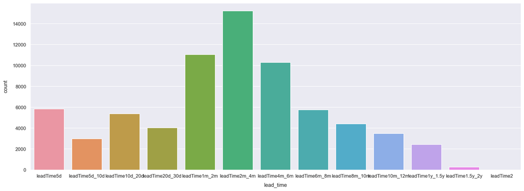

```python
order = ['leadTime5d','leadTime5d_10d','leadTime10d_20d','leadTime20d_30d','leadTime1m_2m','leadTime2m_4m','leadTime4m_6m','leadTime6m_8m','leadTime8m_10m','leadTime10m_12m','leadTime1y_1.5y','leadTime1.5y_2y','leadTime2']
#城市酒店
plt.rcParams['figure.figsize'] = (20, 7)
sns.countplot(subCDF['lead_time'],order=order)
```

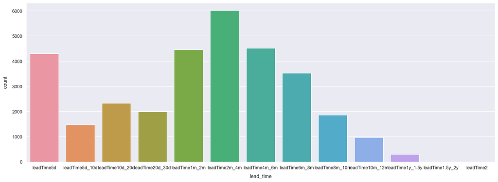

```python
#假日酒店
sns.countplot(subRDF['lead_time'],order= order)
```

### 对比两者的预订提前日期，可以看出假日酒店和城市酒店用户最多的是提前2-4月预订，其次是提前1-2个月或者4-6个月。同时假日酒店不同于城市酒店，用户提前五天以内预订的数量除以上时间段是最高的，而城市酒店提前五天以内的用户数量并不突出。两者提前时间在8月以上的用户都不多。

```python
tempDate=datetime.date(2000,1,1)
df['arrival_time']=tempDate
def setDate(x):
    x['arrival_time']=datetime.date(x['arrival_date_year'],x['arrival_date_month'],x['arrival_date_day_of_month'])
    return x
df = df.apply(setDate,axis=1)
```

```python
df['reservation_status_date']= pd.to_datetime(df['reservation_status_date'])
df['arrival_time']= pd.to_datetime(df['arrival_time'])
df['stay_time']=(df['reservation_status_date']-df['arrival_time']).dt.days
```

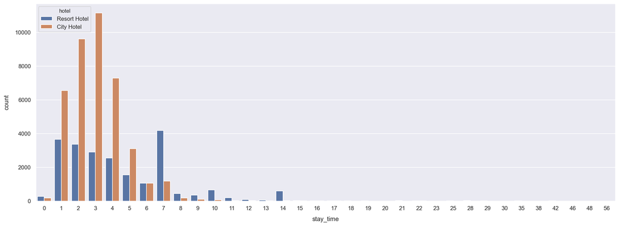

```python
#对比未取消预订的入住时长
sns.countplot(x="stay_time", hue="hotel", data=df[df['is_canceled']==0])
```

### 从图中可以发现，假日酒店入住时长最多的为7天其次是1天；而城市酒店入住时长最多的是3天其次是2天，并且集中在1,2,3,4这个时长。

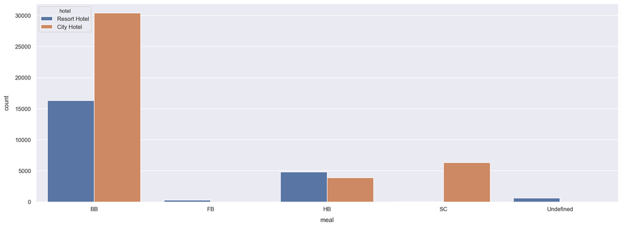

```python
sns.countplot(x="meal", hue="hotel", data=df[df['is_canceled']==0])
```

### 3.3 一年中最佳预订酒店时间

```python
from  datetime import *

#计算预订时间和月份，以及取消预订的月份
df['book_time']=tempDate
df['book_month']=tempDate.month
df['canceled_month']=0
def getBookDate(x):
    x['book_time'] = x['arrival_time']-timedelta(days=x['lead_time'])
    x['book_month'] = x['book_time'].month
    if x['is_canceled']==1:
        x['canceled_month'] = x['reservation_status_date'].month
    return x
df = df.apply(getBookDate,axis=1)
```

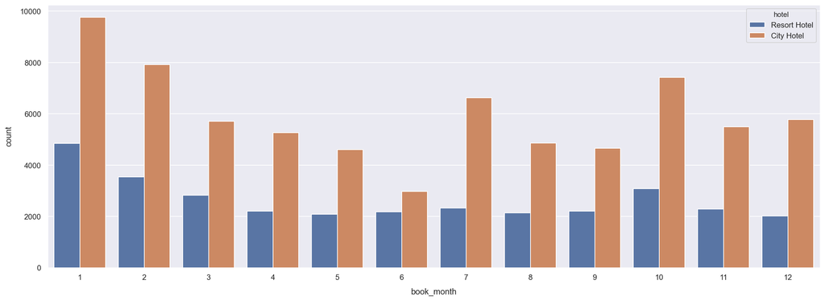

```python
sns.countplot(x="book_month", hue="hotel",data=df)
```

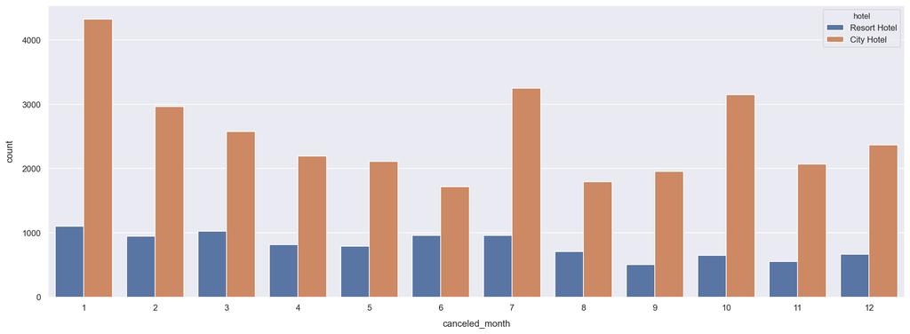

```python
sns.countplot(x="canceled_month", hue="hotel",data=df[df['is_canceled']==1])
```

## 4 利用Logistic预测酒店预订

### 4.1 将分类值编码为数值。使用map函数修改和使用LabelEncode库。

```python
labelencoder=LabelEncoder()

df.drop(['arrival_time','stay_time','book_month','canceled_month'],axis=1,inplace=True)

df['hotel']=df['hotel'].map({'Resort Hotel':0,'City Hotel':1})
df['meal']=labelencoder.fit_transform(df['meal'])
df['country']=labelencoder.fit_transform(df['country'])
df['market_segment']=labelencoder.fit_transform(df['market_segment'])
df['distribution_channel']=labelencoder.fit_transform(df['distribution_channel'])
df['reserved_room_type']=labelencoder.fit_transform(df['reserved_room_type'])
df['assigned_room_type']=labelencoder.fit_transform(df['assigned_room_type'])
df['deposit_type']=labelencoder.fit_transform(df['deposit_type'])
df['customer_type']=labelencoder.fit_transform(df['customer_type'])
df['reservation_status']=labelencoder.fit_transform(df['reservation_status'])
df['reservation_status_date']=labelencoder.fit_transform(df['reservation_status_date'])
df['book_time']=labelencoder.fit_transform(df['book_time'])
```

### 4.2 并非所有属性都相关，并且与输出属性模式匹配。因此用输出属性来提取相关属性，忽略其余的属性。

```python
correlation=df.corr()['is_canceled']
correlation.abs().sort_values(ascending=False)
```

```
is_canceled                       1.000000
reservation_status                0.921762
deposit_type                      0.459030
country                           0.296892
lead_time                         0.277257
total_of_special_requests         0.258166
required_car_parking_spaces       0.188501
reservation_status_date           0.180765
assigned_room_type                0.164775
booking_changes                   0.131177
previous_cancellations            0.117976
hotel                             0.116743
book_time                         0.107752
distribution_channel              0.097846
agent                             0.082212
reserved_room_type                0.062040
customer_type                     0.060675
days_in_waiting_list              0.052592
previous_bookings_not_canceled    0.042478
market_segment                    0.038830
adults                            0.034531
babies                            0.032110
meal                              0.029645
is_repeated_guest                 0.027919
stays_in_weekend_nights           0.023456
adr                               0.022091
arrival_date_month                0.006615
arrival_date_day_of_month         0.005392
children                          0.005213
arrival_date_year                 0.004671
stays_in_week_nights              0.004187
Name: is_canceled, dtype: float64
```

#### 使用meal属性以上的属性列

```python
cols=['is_repeated_guest','stays_in_weekend_nights','adr','arrival_date_month','arrival_date_day_of_month','children',
     'arrival_date_year','stays_in_week_nights']
df=df.drop(cols,axis=1)
print(df.shape)
```

```
(102774, 23)
```

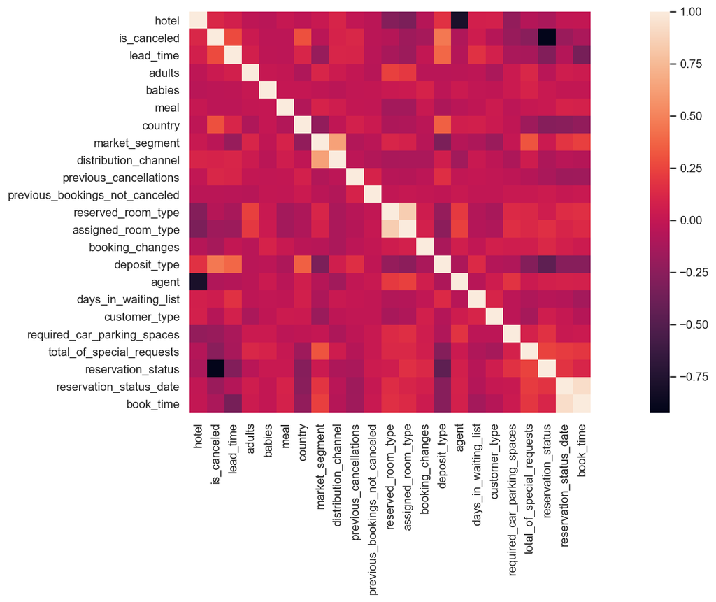

```python
data_corr=df.corr()
sns.heatmap(data_corr,square=True)
```

### 4.3 将数据集划分为输入输出属性

```python
y=df['is_canceled'].values
x=df.drop(['is_canceled'],axis=1).values
```

### 4.4 将数据集分为训练集和测试集

```python
#  数据及划分
train_size=0.80
test_size=0.20
seed=5

x_train,x_test,y_train,y_test=train_test_split(x,y,train_size=train_size,test_size=test_size,random_state=seed)
```

### 4.5 建模

```python
import matplotlib.pyplot as plt
from sklearn.linear_model import LogisticRegression

# 评估
from sklearn.model_selection import KFold
from sklearn.model_selection import cross_val_score

error='accuracy'
fold=KFold(n_splits=10,random_state=0)
result=cross_val_score(LogisticRegression(),x_train,y_train,cv=fold,scoring=error)
msg="%s : %f (%f)"%('LogisticRegression',result.mean(),result.std())
print(msg)


# # Visualizing the Model accuracy
# fig=plt.figure()
# fig.suptitle("Comparing Algorithms")
# plt.boxplot(predictions)
# plt.show()
```

[output not shown]

[output cut: 19 more lines]

[output not shown]

```
LogisticRegression : 0.936256 (0.025551)
```

[output not shown]

```python
# 逻辑回归算法参数调优
from sklearn.model_selection import GridSearchCV
from sklearn. preprocessing import StandardScaler

scaler=StandardScaler().fit(x_train)
rescaledx=scaler.transform(x_train)
c=[0.1,0.2,0.3,0.4,0.5,0.6,0.7,0.8,0.9,1.0]
param_grid=dict(C=c)
model=LogisticRegression()
fold=KFold(n_splits=10,random_state=5)
grid=GridSearchCV(estimator=model,param_grid=param_grid,scoring=error,cv=fold)
grid_result=grid.fit(rescaledx,y_train)

print("Best: %f using %s "%(grid_result.best_score_,grid_result.best_params_))
```

```
e:\python 3.7.6\lib\site-packages\sklearn\model_selection\_split.py:297: FutureWarning: Setting a random_state has no effect since shuffle is False. This will raise an error in 0.24. You should leave random_state to its default (None), or set shuffle=True.
  FutureWarning
```

```
Best: 0.989735 using {'C': 0.1}
```

#### 将正则化调整应用于逻辑回归算法后，得到逻辑回归分类器最佳为：0.989735，使用参数{'C'：0.1}

```python
#应用参数，完成模型
from sklearn.metrics import confusion_matrix
from sklearn.metrics import accuracy_score
scaler=StandardScaler().fit(x_train)
scaler_x=scaler.transform(x_train)
model=LogisticRegression(C=0.1)
model.fit(scaler_x,y_train)

#Transform the validation test set data
scaledx_test=scaler.transform(x_test)
y_pred=model.predict(scaledx_test)

accuracy_mean=accuracy_score(y_test,y_pred)
accuracy_matric=confusion_matrix(y_test,y_pred)
print(accuracy_mean)
print(accuracy_matric)
```

```
0.9909511067866699
[[12526     6]
 [  180  7843]]
```

#### 在训练和测试集上获得了99.09％的准确性。根据混淆矩阵可以看到只有6个0被错分为1，180个1被错分为0